# lab 5 report for BIOS 20152

Sarah Greta

## Part 1: simulation of a two state model of infection

In this section you will simulate a two-state Markov model, by starting with a value of the state variable, using a random number and an if statement to generate the next value, and then the next one, and so on. Since Markov models are inherently random, each simulation will result in a different sequence of states.

Consider a simple model of an infectious epidemic, in which the population consists of only two types of people: susceptible (S) and infected (I). Suppose that the transition probabilities are (per day): 0.04 (from S to I) and 0.12 (from I to S). The first task asks you to write a script to decide, based on the initial state of the person (S or I), what state they are in the next day. Task 1.2 asks you to repeat that decision (using a for loop) to generate a string of states (S and I) over a given number of days, which you will save as a vector.

You will then count the number of days the person spent in each state (S or I) and plot the histogam using the functions **barplot()** and **table()** (illustrated below on a randomly generated vector of zeros and ones):

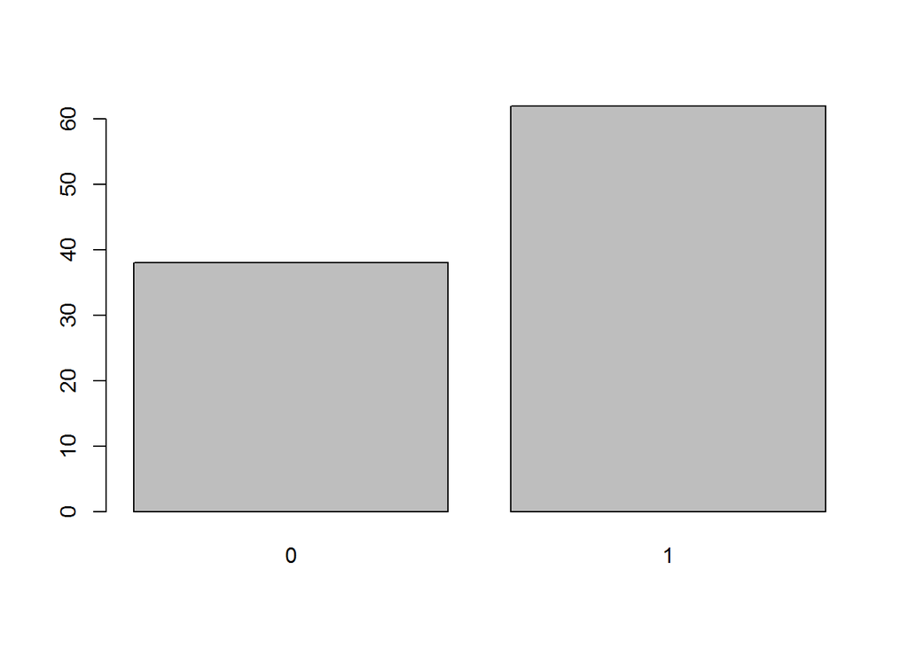

```r
random.vec <- rbinom(100,1,0.5)
barplot(table(random.vec))
```

Since this is a random simulation, you will get different strings of states every time your run your code. You don’t need to copy and paste your code to run it repeatedly, simply choose (run current chunk) as many times as you need, and report the results in words.

1. Write a script to a make a random decision for an individual based on the SI Markov model, where you set the initial state to be either 1 (S) or 2 (I). The script should first use an *if* statement to check whether the state is 1 or *else* is 2 and then use the transition probabilities given above to make the random decision. Run this script a few times to make sure it transitions from both state 1 to 2, and from 2 to 1 (remember that it’s a random decision, so don’t worry if the transition doesn’t happen as often as you’d expect) and report the results of your experimentation.

```r
in.state <- 1
trans1to2 <- 0.04
trans2to1 <- 0.12
decider <- runif(1)
if (in.state==1) {
  if (decider < trans1to2){
    new.state <- 2
  } else {
    new.state <- 1
  }
}
print(new.state)
```

```
## [1] 1
```

2. Add a for loop around your previous script to generate a state string over 100 days for an individual given an an initial state. Change your state variable into a vector (e.g. *state.vec*) and save the states for each day (labeled with numbers 1 and 2 for S and I). Plot that vector variable using *plot(state.vec)* to visualize the simulated disease history of one person and plot the histogram of state frequencies using the command *barplot(table(state.vec))*. Re-run the script five times to see different disease histories and report the fraction of days each of these “people” spend infected.

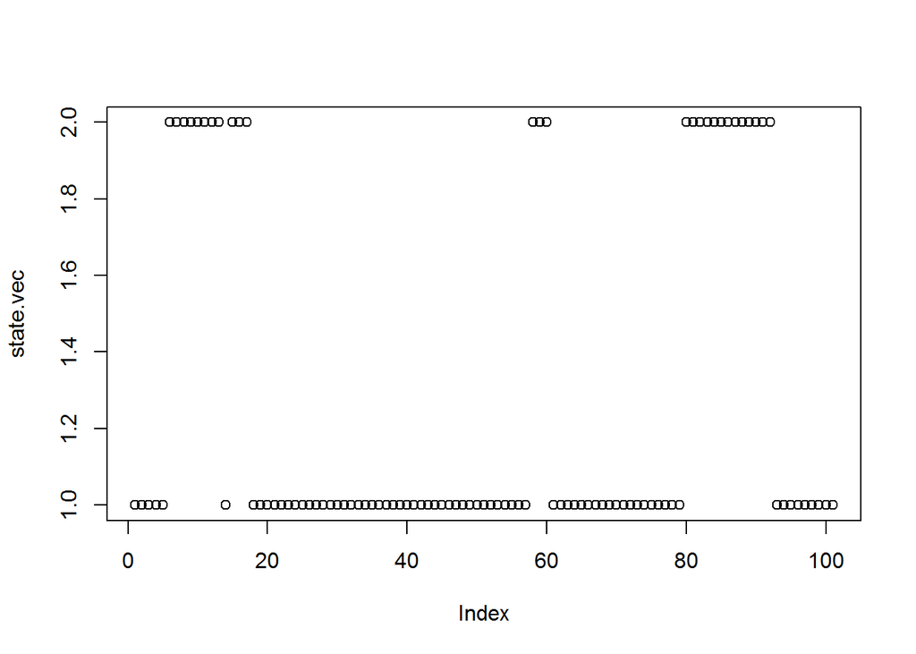

```r
in.state <- 1
nsteps <- 100
state.vec <- rep(in.state, nsteps+1)
for (i in 1:nsteps) {
decider <- runif(1)
if (state.vec[i]==1) {
  if (decider < trans1to2){
    state.vec[i+1] <- 2
  } else {
    state.vec[i+1] <- 1
  }
} else if (state.vec[i]==2) {
    if (decider < trans2to1) {
      state.vec[i+1] <- 1
    } else {
      state.vec[i+1] <- 2
    }
}
}
plot(state.vec)
```

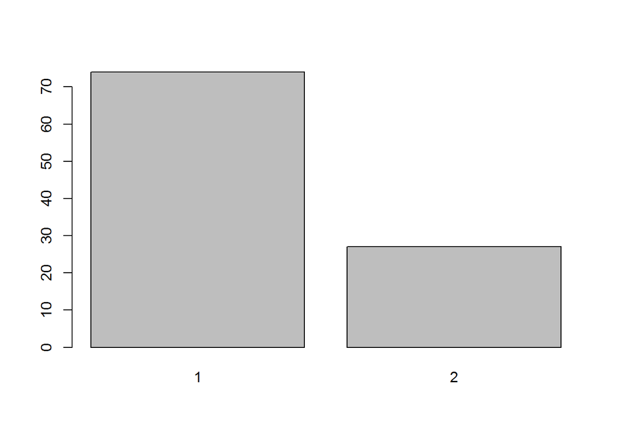

```r
barplot(table(state.vec))
```

3. Change the infection rate (transition from S to I) to 0.2, and repeat the computations in the last task. Re-run the script five times to see different disease histories and report the fraction of days these “people” spend infected. How does it compare to the fraction in the previous task?

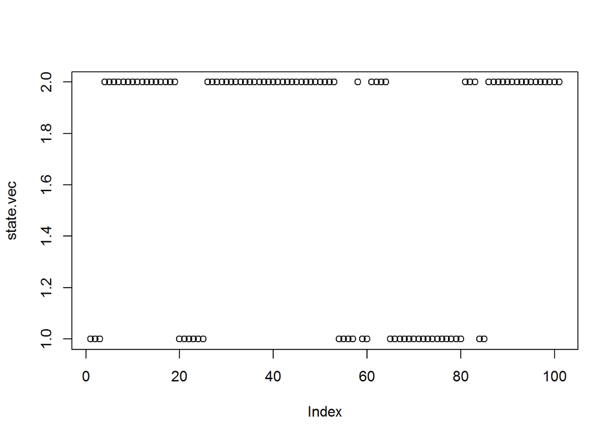

```r
trans1to2 <- 0.2
state.vec <- rep(in.state, nsteps+1)
for (i in 1:nsteps) {
decider <- runif(1)
if (state.vec[i]==1) {
  if (decider < trans1to2){
    state.vec[i+1] <- 2
  } else {
    state.vec[i+1] <- 1
  }
} else if (state.vec[i]==2) {
    if (decider < trans2to1) {
      state.vec[i+1] <- 1
    } else {
      state.vec[i+1] <- 2
    }
}
}
plot(state.vec)
```

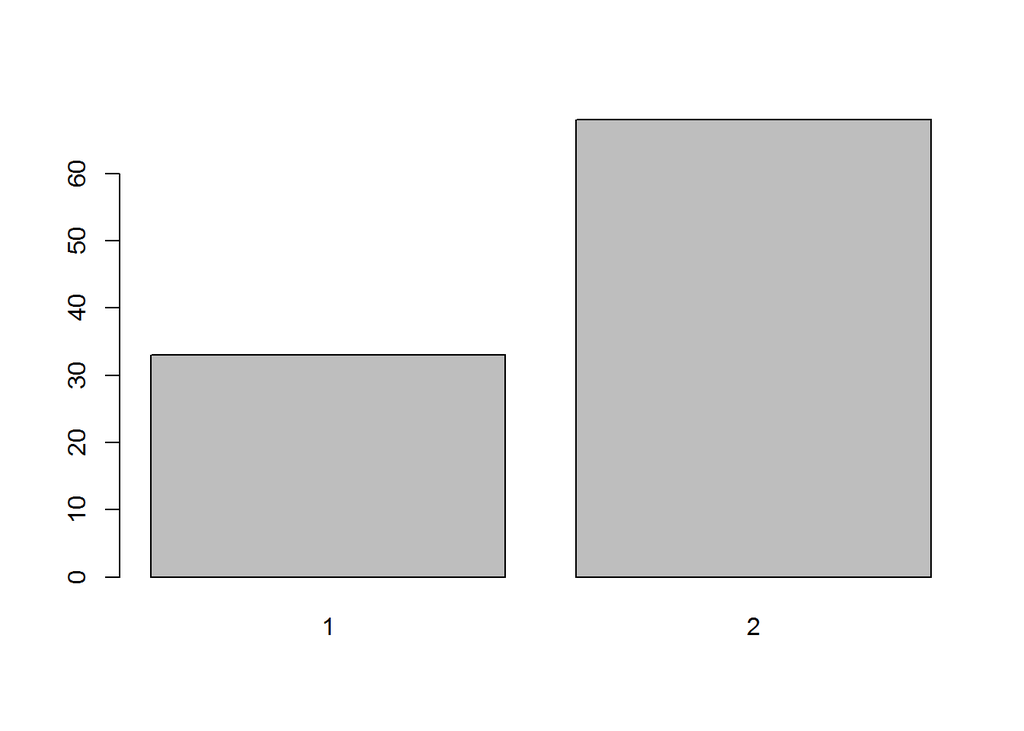

```r
barplot(table(state.vec))
```

In the first run, the people spent 55% of the days infected. In the second run, the people spent 60% of the days infected. In the third run, the people spent 80% of the days infected. In the fourth run, the people spent 55% of the days days. In the final run, the people spent 60% of the days infected. In these runs, more people stay infected for longer because the transition rate of susceptible to infected increased.

4. Change the recovery rate (transition from I to S) to 0.6, and repeat the computations in the last task. Re-run the script five times to see different disease histories and report the fraction of days these “people” spend infected. How does it compare to the fraction in the last two tasks?

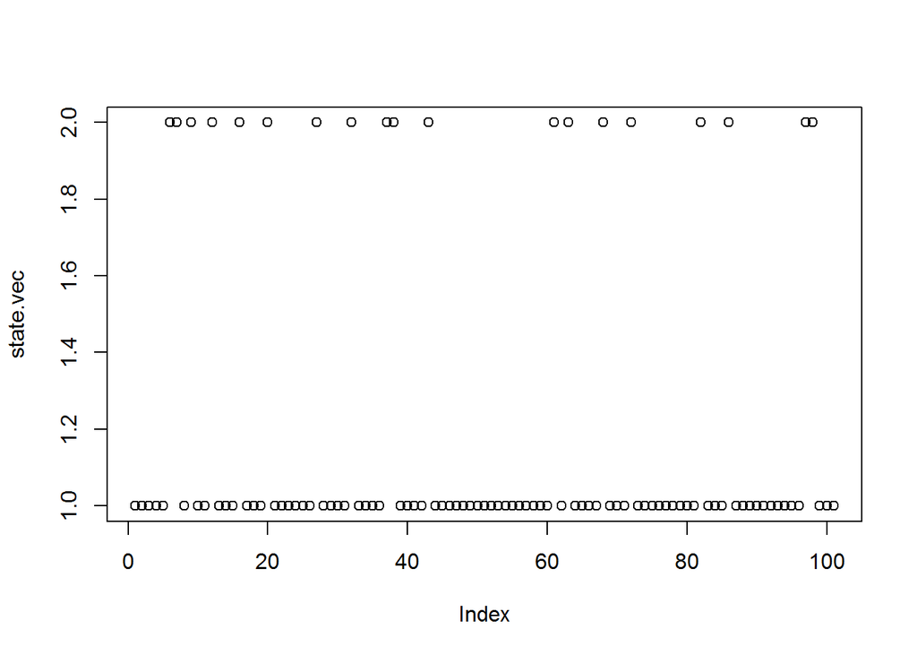

```r
trans2to1 <- 0.6
state.vec <- rep(in.state, nsteps+1)
for (i in 1:nsteps) {
decider <- runif(1)
if (state.vec[i]==1) {
  if (decider < trans1to2){
    state.vec[i+1] <- 2
  } else {
    state.vec[i+1] <- 1
  }
} else if (state.vec[i]==2) {
    if (decider < trans2to1) {
      state.vec[i+1] <- 1
    } else {
      state.vec[i+1] <- 2
    }
}
}
plot(state.vec)
```

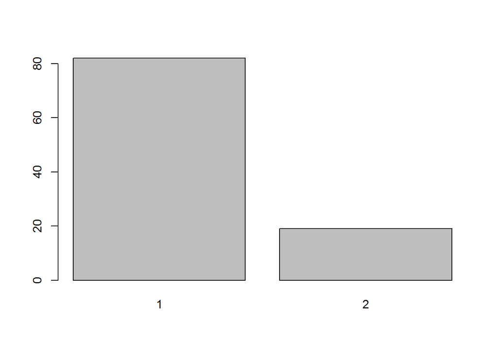

```r
barplot(table(state.vec))
```

In the first run, the people spent 25% of the days infected. In the second run, the people spent 30% of the days infected. In the third run, the people spent 25% of the days infected. In the fourth run, the people spent 20% of the days infected. In the final run, the people spent 20% of the days infected. In these runs, fewer people stayed infected for longer because the transition rate from infected to susceptible increased.

## Part 2: simulation of a three state model of an ion channel

Ion channels are trans-membrane proteins with a hollow channel running through the interior that allows polar ions to traverse the nonpolar lipid bilayer. The channels may exist in several conformations (shapes), which may either allow or block passage of ions through the channel. Transitions between the conformational states are random (as is everything on the molecular scale), but they may be influenced by external events, such as binding of another molecule, or a change in membrane potential.

In this section you will construct and analyze a simple model of nicotinic acetylcholine receptor (nAChR), which is an important ion channel involved in transmission of signals between neurons. The opening of the channel is induced by binding of the neurotransmitter acetylcholine (Ach). The Markov chain model has three states: closed (C1), closed with Ach bound (C2), and open (O). Suppose that at a certain concentration of Ach, the transition probabilities between the different states are as follows (per one microsecond): 0.04 (from C1 to C2), 0.07 (from C2 to C1), 0.12 (from C2 to O) and 0.02 (from O to C2); the other transition probabilities are 0.

1. Write a script to a make a random decision for a single ion channel based on the Markov model above, where you set the initial state to C2 (because it can transition to either C1 or O). The script should use an *if* statement followed by *else if* to check whether the state is 1 (C1), 2 (C2), or *else* is 3 (O); then use the transition probabilities given above to make the random decision. Run this script a few times to make sure it transitions from C2 to both C1 and O and report the results of your experimentation.

```r
in.state <- 2
trans2to1 <- 0.07
trans2to0 <- 0.19
decider <- runif(1)
if (in.state==2) {
  if (decider < trans2to1){
    new.state <- 1
  } else  if (decider < trans2to0) {
    new.state <- 0
  } else {
    new.state <- 2
  }
}
print(new.state)
```

```
## [1] 1
```

Most of the time, the channel remains in state 2 (closed with Ach bound), which makes sense because the transition probability from 2 to 1 and 2 to 0 are fairly low. A transition from state 2 to state 0 is rare, but it is more common than a transition from state 2 to state 1.

2. Add a for loop around your previous script to generate a state string over 1000 microseconds for an ion channel starting with state C1 (1). Change your state variable into a vector, and save the states for each day (labeled with numbers 1, 2, and 3 for the states) into a vector (e.g *state.vec*). Plot that vector variable using *plot(state.vec)* to visualize the simulated history of an ion channel and plot the histogram of state frequencies using the command *barplot(table(state.vec))*. Re-run the script five times to see different ion channel state histories and report the fraction of time these ion channels are open.

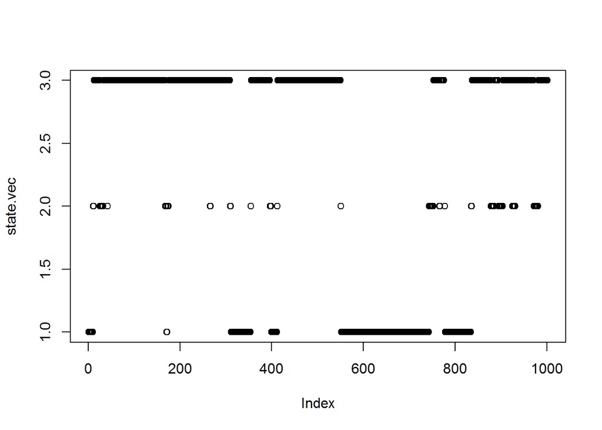

```r
in.state <- 1
trans2to1 <- 0.07
trans2to3 <- 0.19
trans1to2 <- 0.04
trans3to2 <- 0.02
nsteps <- 1000
state.vec <- rep(NA, nsteps+1)
state.vec[1] <- in.state
for (i in 1:nsteps) {
decider <- runif(1)
current.state <- state.vec[i]
if (current.state==1) {
  if (decider < trans1to2){
    state.vec[i+1] <- 2
  } else {
    state.vec[i+1] <- 1
  }
} else if (current.state==2) {
    if (decider < trans2to1) {
      state.vec[i+1] <- 1
    } else if (decider < trans2to3) {
      state.vec[i+1] <- 3
    } else {
      state.vec[i+1] <- 2
    }
  } else if (current.state==3) {
      if (decider < trans3to2) {
        state.vec[i+1] <- 2
      } else {
        state.vec[i+1] <- 3
    }
}
}
plot(state.vec)
```

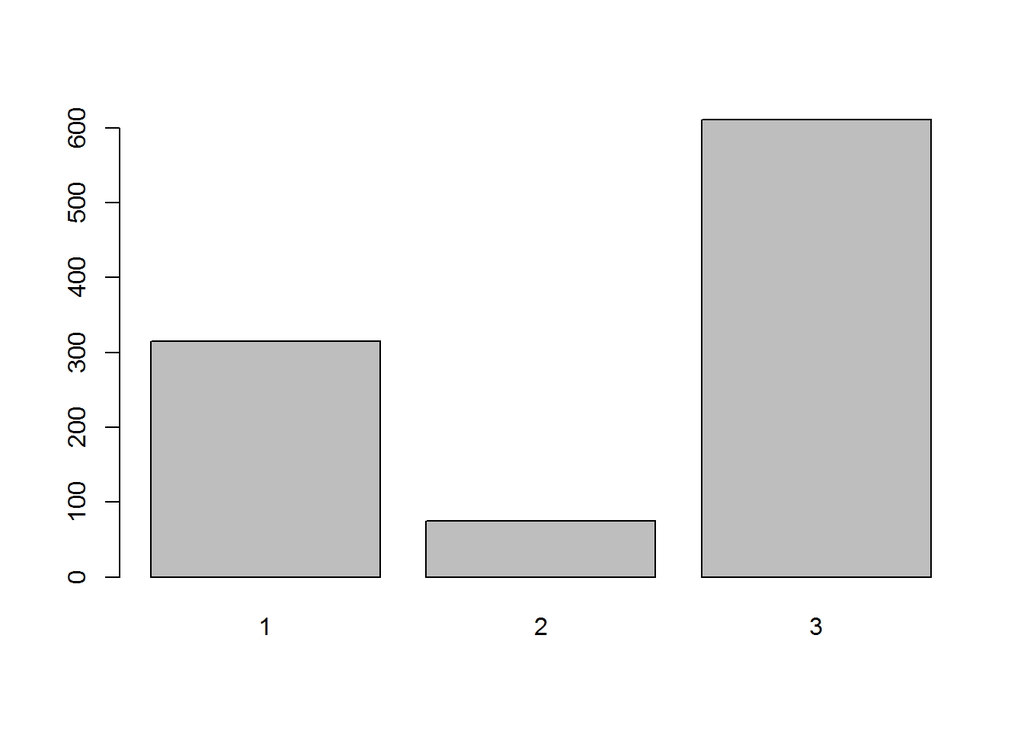

```r
barplot(table(state.vec))
```

In the first run, the channel was open 75% of the time. In the second run, the channel was open 75% of the time. In the third run, the channel was open 65% of the time. In the fourth run, the channel was open 75% of the time. In the final run, the channel was open 55% of the time.

3. Change the opening rate (transition from C2 to O) to 0.02, and repeat the computations in the last task, Re-run the script five times to see different ion channel state histories and report the fraction of time these ion channels are open. Compare the fractions to the results in the previous task and describe the effect of changing the transition probability on the long-term probability of the channel being open.

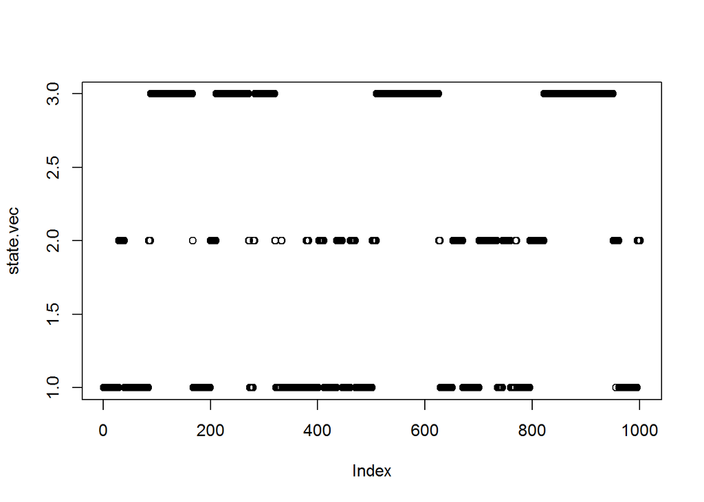

```r
trans2to3 <- 0.09
nsteps <- 1000
state.vec <- rep(NA, nsteps+1)
state.vec[1] <- in.state
for (i in 1:nsteps) {
decider <- runif(1)
current.state <- state.vec[i]
if (current.state==1) {
  if (decider < trans1to2){
    state.vec[i+1] <- 2
  } else {
    state.vec[i+1] <- 1
  }
} else if (current.state==2) {
    if (decider < trans2to1) {
      state.vec[i+1] <- 1
    } else if (decider < trans2to3) {
      state.vec[i+1] <- 3
    } else {
      state.vec[i+1] <- 2
    }
  } else if (current.state==3) {
      if (decider < trans3to2) {
        state.vec[i+1] <- 2
      } else {
        state.vec[i+1] <- 3
    }
}
}
plot(state.vec)
```

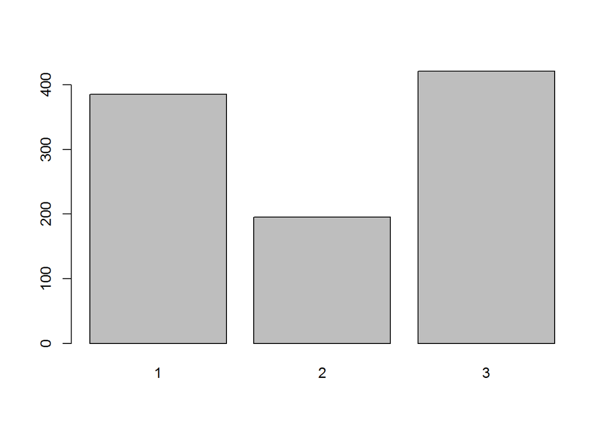

```r
barplot(table(state.vec))
```